# FCD Trab Grupo 2

```python
import pandas as pd
from tkinter import filedialog
from summarytools import dfSummary
import matplotlib.pyplot as plt
```

File path

```python
# Display the dialog for browsing files
filename = filedialog.askopenfilename()

# Print the selected file path.
print(filename)
```

[output not shown]

```
/Users/andrepirex/Downloads/vehicles.csv
```

Create a dataframe of the CVS file

```python
dataset_original=pd.read_csv(filename)
```

Start the Descriptive analysis

Size of the Dataset - display the number of observations and attributes

```python
dataset_original.shape
```

```
(426880, 26)
```

Head of dataset - display the first 5 rows of the dataset

```python
dataset_original.head()
```

|  | id | url | region | region_url | price | year | manufacturer | model | condition | cylinders | ... | size | type | paint_color | image_url | description | county | state | lat | long | posting_date |
| --- | --- | --- | --- | --- | --- | --- | --- | --- | --- | --- | --- | --- | --- | --- | --- | --- | --- | --- | --- | --- | --- |
| 0 | 7222695916 | https://prescott.craigslist.org/cto/d/prescott... | prescott | https://prescott.craigslist.org | 6000 | NaN | NaN | NaN | NaN | NaN | ... | NaN | NaN | NaN | NaN | NaN | NaN | az | NaN | NaN | NaN |
| 1 | 7218891961 | https://fayar.craigslist.org/ctd/d/bentonville... | fayetteville | https://fayar.craigslist.org | 11900 | NaN | NaN | NaN | NaN | NaN | ... | NaN | NaN | NaN | NaN | NaN | NaN | ar | NaN | NaN | NaN |
| 2 | 7221797935 | https://keys.craigslist.org/cto/d/summerland-k... | florida keys | https://keys.craigslist.org | 21000 | NaN | NaN | NaN | NaN | NaN | ... | NaN | NaN | NaN | NaN | NaN | NaN | fl | NaN | NaN | NaN |
| 3 | 7222270760 | https://worcester.craigslist.org/cto/d/west-br... | worcester / central MA | https://worcester.craigslist.org | 1500 | NaN | NaN | NaN | NaN | NaN | ... | NaN | NaN | NaN | NaN | NaN | NaN | ma | NaN | NaN | NaN |
| 4 | 7210384030 | https://greensboro.craigslist.org/cto/d/trinit... | greensboro | https://greensboro.craigslist.org | 4900 | NaN | NaN | NaN | NaN | NaN | ... | NaN | NaN | NaN | NaN | NaN | NaN | nc | NaN | NaN | NaN |

5 rows × 26 columns

Type of the attributes - display the categories of data for each feature

```python
dataset_original.dtypes
```

```
id                int64
url              object
region           object
region_url       object
price             int64
year            float64
manufacturer     object
model            object
condition        object
cylinders        object
fuel             object
odometer        float64
title_status     object
transmission     object
VIN              object
drive            object
size             object
type             object
paint_color      object
image_url        object
description      object
county          float64
state            object
lat             float64
long            float64
posting_date     object
dtype: object
```

Localization Measures - display the some statistical measures for numerical attributes

```python
dataset_original.describe().map(lambda x: f"{x:0.1f}") #round the decimals up to 1 decimal
```

|  | id | price | year | odometer | county | lat | long |
| --- | --- | --- | --- | --- | --- | --- | --- |
| count | 426880.0 | 426880.0 | 425675.0 | 422480.0 | 0.0 | 420331.0 | 420331.0 |
| mean | 7311486634.2 | 75199.0 | 2011.2 | 98043.3 | nan | 38.5 | -94.7 |
| std | 4473170.4 | 12182282.2 | 9.5 | 213881.5 | nan | 5.8 | 18.4 |
| min | 7207408119.0 | 0.0 | 1900.0 | 0.0 | nan | -84.1 | -159.8 |
| 25% | 7308143339.2 | 5900.0 | 2008.0 | 37704.0 | nan | 34.6 | -111.9 |
| 50% | 7312620821.0 | 13950.0 | 2013.0 | 85548.0 | nan | 39.2 | -88.4 |
| 75% | 7315253543.5 | 26485.8 | 2017.0 | 133542.5 | nan | 42.4 | -80.8 |
| max | 7317101084.0 | 3736928711.0 | 2022.0 | 10000000.0 | nan | 82.4 | 173.9 |

Exploratory Data Analysis (EDA) with summarytools library - display to frequency of the values in the dataset, number of missing values, plot data, and other statistics

**Data Frame Summary**  
dataset_original  
Dimensions: 426,880 x 26  
Duplicates: 0

No

Variable

Stats / Values

Freqs / (% of Valid)

Graph

Missing

1

**id**  
[int64]

Mean (sd) : 7311486634.2 (4473170.4)  
min < med < max:  
7207408119.0 < 7312620821.0 < 7317101084.0  
IQR (CV) : 7110204.2 (1634.5)

426,880 distinct values

0  
(0.0%)

2

**url**  
[object]

1. https://wyoming.craigslist.org  
2. https://wyoming.craigslist.org  
3. https://wyoming.craigslist.org  
4. https://wyoming.craigslist.org  
5. https://wyoming.craigslist.org  
6. https://wyoming.craigslist.org  
7. https://wyoming.craigslist.org  
8. https://wyoming.craigslist.org  
9. https://wyoming.craigslist.org  
10. https://wyoming.craigslist.org  
11. other

1 (0.0%)  
1 (0.0%)  
1 (0.0%)  
1 (0.0%)  
1 (0.0%)  
1 (0.0%)  
1 (0.0%)  
1 (0.0%)  
1 (0.0%)  
1 (0.0%)  
426,870 (100.0%)

0  
(0.0%)

3

**region**  
[object]

1. columbus  
2. jacksonville  
3. spokane / coeur d'alene  
4. eugene  
5. fresno / madera  
6. orlando  
7. omaha / council bluffs  
8. bend  
9. new hampshire  
10. kennewick-pasco-richland  
11. other

3,608 (0.8%)  
3,562 (0.8%)  
2,988 (0.7%)  
2,985 (0.7%)  
2,983 (0.7%)  
2,983 (0.7%)  
2,982 (0.7%)  
2,982 (0.7%)  
2,981 (0.7%)  
2,981 (0.7%)  
395,845 (92.7%)

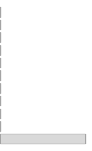

0  
(0.0%)

4

**region_url**  
[object]

1. https://spokane.craigslist.org  
2. https://eugene.craigslist.org  
3. https://orlando.craigslist.org  
4. https://fresno.craigslist.org  
5. https://omaha.craigslist.org  
6. https://bend.craigslist.org  
7. https://nh.craigslist.org  
8. https://kpr.craigslist.org  
9. https://nashville.craigslist.o  
10. https://salem.craigslist.org  
11. other

2,988 (0.7%)  
2,985 (0.7%)  
2,983 (0.7%)  
2,983 (0.7%)  
2,982 (0.7%)  
2,982 (0.7%)  
2,981 (0.7%)  
2,981 (0.7%)  
2,980 (0.7%)  
2,980 (0.7%)  
397,055 (93.0%)

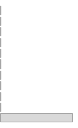

0  
(0.0%)

5

**price**  
[int64]

Mean (sd) : 75199.0 (12182282.2)  
min < med < max:  
0.0 < 13950.0 < 3736928711.0  
IQR (CV) : 20585.8 (0.0)

15,655 distinct values

0  
(0.0%)

6

**year**  
[float64]

Mean (sd) : 2011.2 (9.5)  
min < med < max:  
1900.0 < 2013.0 < 2022.0  
IQR (CV) : 9.0 (212.8)

114 distinct values

1,205  
(0.3%)

7

**manufacturer**  
[object]

1. ford  
2. chevrolet  
3. toyota  
4. honda  
5. nissan  
6. jeep  
7. ram  
8. nan  
9. gmc  
10. bmw  
11. other

70,985 (16.6%)  
55,064 (12.9%)  
34,202 (8.0%)  
21,269 (5.0%)  
19,067 (4.5%)  
19,014 (4.5%)  
18,342 (4.3%)  
17,646 (4.1%)  
16,785 (3.9%)  
14,699 (3.4%)  
139,807 (32.8%)

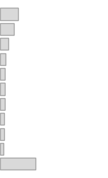

17,646  
(4.1%)

8

**model**  
[object]

1. f-150  
2. nan  
3. silverado 1500  
4. 1500  
5. camry  
6. silverado  
7. accord  
8. wrangler  
9. civic  
10. altima  
11. other

8,009 (1.9%)  
5,277 (1.2%)  
5,140 (1.2%)  
4,211 (1.0%)  
3,135 (0.7%)  
3,023 (0.7%)  
2,969 (0.7%)  
2,848 (0.7%)  
2,799 (0.7%)  
2,779 (0.7%)  
386,690 (90.6%)

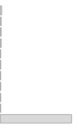

5,277  
(1.2%)

9

**condition**  
[object]

1. nan  
2. good  
3. excellent  
4. like new  
5. fair  
6. new  
7. salvage

174,104 (40.8%)  
121,456 (28.5%)  
101,467 (23.8%)  
21,178 (5.0%)  
6,769 (1.6%)  
1,305 (0.3%)  
601 (0.1%)

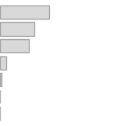

174,104  
(40.8%)

10

**cylinders**  
[object]

1. nan  
2. 6 cylinders  
3. 4 cylinders  
4. 8 cylinders  
5. 5 cylinders  
6. 10 cylinders  
7. other  
8. 3 cylinders  
9. 12 cylinders

177,678 (41.6%)  
94,169 (22.1%)  
77,642 (18.2%)  
72,062 (16.9%)  
1,712 (0.4%)  
1,455 (0.3%)  
1,298 (0.3%)  
655 (0.2%)  
209 (0.0%)

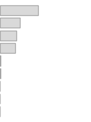

177,678  
(41.6%)

11

**fuel**  
[object]

1. gas  
2. other  
3. diesel  
4. hybrid  
5. nan  
6. electric

356,209 (83.4%)  
30,728 (7.2%)  
30,062 (7.0%)  
5,170 (1.2%)  
3,013 (0.7%)  
1,698 (0.4%)

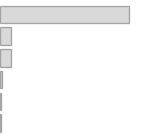

3,013  
(0.7%)

12

**odometer**  
[float64]

Mean (sd) : 98043.3 (213881.5)  
min < med < max:  
0.0 < 85548.0 < 10000000.0  
IQR (CV) : 95838.5 (0.5)

104,870 distinct values

4,400  
(1.0%)

13

**title_status**  
[object]

1. clean  
2. nan  
3. rebuilt  
4. salvage  
5. lien  
6. missing  
7. parts only

405,117 (94.9%)  
8,242 (1.9%)  
7,219 (1.7%)  
3,868 (0.9%)  
1,422 (0.3%)  
814 (0.2%)  
198 (0.0%)

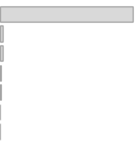

8,242  
(1.9%)

14

**transmission**  
[object]

1. automatic  
2. other  
3. manual  
4. nan

336,524 (78.8%)  
62,682 (14.7%)  
25,118 (5.9%)  
2,556 (0.6%)

2,556  
(0.6%)

15

**VIN**  
[object]

1. nan  
2. 1FMJU1JT1HEA52352  
3. 3C6JR6DT3KG560649  
4. 1FTER1EH1LLA36301  
5. 5TFTX4CN3EX042751  
6. 1GCHTCE37G1186784  
7. 1GTN1TEH5EZ273019  
8. 3VWF17AT1FM655022  
9. JN1AZ4EH8KM420880  
10. 1FTMF1CP3GKD62143  
11. other

161,042 (37.7%)  
261 (0.1%)  
235 (0.1%)  
231 (0.1%)  
227 (0.1%)  
214 (0.1%)  
207 (0.0%)  
199 (0.0%)  
198 (0.0%)  
195 (0.0%)  
263,871 (61.8%)

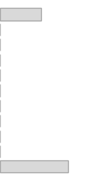

161,042  
(37.7%)

16

**drive**  
[object]

1. 4wd  
2. nan  
3. fwd  
4. rwd

131,904 (30.9%)  
130,567 (30.6%)  
105,517 (24.7%)  
58,892 (13.8%)

130,567  
(30.6%)

17

**size**  
[object]

1. nan  
2. full-size  
3. mid-size  
4. compact  
5. sub-compact

306,361 (71.8%)  
63,465 (14.9%)  
34,476 (8.1%)  
19,384 (4.5%)  
3,194 (0.7%)

306,361  
(71.8%)

18

**type**  
[object]

1. nan  
2. sedan  
3. SUV  
4. pickup  
5. truck  
6. other  
7. coupe  
8. hatchback  
9. wagon  
10. van  
11. other

92,858 (21.8%)  
87,056 (20.4%)  
77,284 (18.1%)  
43,510 (10.2%)  
35,279 (8.3%)  
22,110 (5.2%)  
19,204 (4.5%)  
16,598 (3.9%)  
10,751 (2.5%)  
8,548 (2.0%)  
13,682 (3.2%)

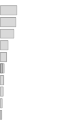

92,858  
(21.8%)

19

**paint_color**  
[object]

1. nan  
2. white  
3. black  
4. silver  
5. blue  
6. red  
7. grey  
8. green  
9. custom  
10. brown  
11. other

130,203 (30.5%)  
79,285 (18.6%)  
62,861 (14.7%)  
42,970 (10.1%)  
31,223 (7.3%)  
30,473 (7.1%)  
24,416 (5.7%)  
7,343 (1.7%)  
6,700 (1.6%)  
6,593 (1.5%)  
4,813 (1.1%)

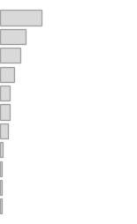

130,203  
(30.5%)

20

**image_url**  
[object]

1. https://images.craigslist.org/  
2. https://images.craigslist.org/  
3. https://images.craigslist.org/  
4. https://images.craigslist.org/  
5. https://images.craigslist.org/  
6. https://images.craigslist.org/  
7. https://images.craigslist.org/  
8. https://images.craigslist.org/  
9. https://images.craigslist.org/  
10. https://images.craigslist.org/  
11. other

7,357 (1.7%)  
2,192 (0.5%)  
276 (0.1%)  
231 (0.1%)  
227 (0.1%)  
213 (0.0%)  
198 (0.0%)  
196 (0.0%)  
195 (0.0%)  
194 (0.0%)  
415,601 (97.4%)

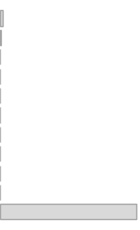

68  
(0.0%)

21

**description**  
[object]

1. 35 VEHICLES PRICED UNDER $3000  
2. Call or text today to find out  
3. This truck has sold, but we bu  
4. CREDIT CARS- $700.00 DOWN- RIG  
5. HEC LEASING, LLC Call Gary, Ru  
6. PLEASE VIEW THE FREE CARFAX HI  
7. 500DOWNNOW.COM!!!!!!!!🌞 🌞 🌞 Am  
8. 🚘 Choose from over 300 vehicle  
9. THIS ONE IS READY TO DRIVE HOM  
10. Don't let your credit hold you  
11. other

231 (0.1%)  
197 (0.0%)  
154 (0.0%)  
148 (0.0%)  
133 (0.0%)  
113 (0.0%)  
90 (0.0%)  
77 (0.0%)  
77 (0.0%)  
76 (0.0%)  
425,584 (99.7%)

70  
(0.0%)

22

**county**  
[float64]

1. nan

426,880 (100.0%)

426,880  
(100.0%)

23

**state**  
[object]

1. ca  
2. fl  
3. tx  
4. ny  
5. oh  
6. or  
7. mi  
8. nc  
9. wa  
10. pa  
11. other

50,614 (11.9%)  
28,511 (6.7%)  
22,945 (5.4%)  
19,386 (4.5%)  
17,696 (4.1%)  
17,104 (4.0%)  
16,900 (4.0%)  
15,277 (3.6%)  
13,861 (3.2%)  
13,753 (3.2%)  
210,833 (49.4%)

[1 more figures not shown]

0  
(0.0%)

24

**lat**  
[float64]

Mean (sd) : 38.5 (5.8)  
min < med < max:  
-84.1 < 39.2 < 82.4  
IQR (CV) : 7.8 (6.6)

53,181 distinct values

6,549  
(1.5%)

25

**long**  
[float64]

Mean (sd) : -94.7 (18.4)  
min < med < max:  
-159.8 < -88.4 < 173.9  
IQR (CV) : 31.1 (-5.2)

53,772 distinct values

6,549  
(1.5%)

26

**posting_date**  
[object]

1. nan  
2. 2021-04-23T22:13:05-0400  
3. 2021-04-22T20:32:05-0400  
4. 2021-04-13T13:19:15-0500  
5. 2021-04-16T12:07:56-0500  
6. 2021-04-30T10:01:13-0400  
7. 2021-04-29T20:06:09-0500  
8. 2021-04-27T15:34:58-0400  
9. 2021-04-05T16:35:08-0400  
10. 2021-04-29T16:25:19-0400  
11. other

68 (0.0%)  
12 (0.0%)  
11 (0.0%)  
11 (0.0%)  
10 (0.0%)  
9 (0.0%)  
9 (0.0%)  
9 (0.0%)  
8 (0.0%)  
8 (0.0%)  
426,725 (100.0%)

68  
(0.0%)

```python
dfSummary(dataset_original)
```

Normalize Data

```python
dataset_original['manufacturer']=dataset_original['manufacturer'].str.lower()
dataset_original['model']=dataset_original['model'].str.lower()
dataset_original['type']=dataset_original['type'].str.lower()
```

Replace Missing values

'type' attribute Goal: create a table with the most commom type of each manufacturer and model

```python
Type_Table=dataset_original[['manufacturer','model', 'type']].dropna().reset_index(drop=True)
Type_Table['MostCommon']=Type_Table.groupby(['manufacturer','model']).cumcount()+1
Type_Table=Type_Table.sort_values(by='MostCommon',ascending=False).reset_index(drop=True)
Type_Table=Type_Table.drop_duplicates(['manufacturer','model']).reset_index(drop=True).drop(['MostCommon'], axis=1)
Type_Table['UniqueReference']=Type_Table['manufacturer'] + Type_Table['model']
Type_Table=Type_Table.drop(['manufacturer','model'],axis=1)
Type_Table
```

|  | type | UniqueReference |
| --- | --- | --- |
| 0 | pickup | fordf-150 |
| 1 | truck | chevroletsilverado 1500 |
| 2 | pickup | ram1500 |
| 3 | sedan | toyotacamry |
| 4 | sedan | hondaaccord |
| ... | ... | ... |
| 20966 | coupe | lincolnmark iii |
| 20967 | coupe | mazdarx& gls sport |
| 20968 | wagon | bmw328d xdrive |
| 20969 | truck | ram1500 laramie 4dr cre |
| 20970 | sedan | dodgecharger rt 4dr sedan |

20971 rows × 2 columns

Detect the duplicates

Count the number of duplicate rows

```python
Number_of_Duplicates = len(dataset_original)-len(dataset_original.drop_duplicates())
print(Number_of_Duplicates)
```

```
0
```

###### There are no duplicates entries, however the same car may be listed in multiple websites because the owners listed it for sell in different states or regions. These situations are easielly identified by counting the VIN of the vehicle. For example VIN "1FMJU1JT1HEA52352", is counted more than one time, so the car is posted in multiple adds in different states or regions.

Count number of duplicated cars by VIN

```python
#group by VIN and show the frequency
dataset_original['VIN'].value_counts()
```

```
VIN
1FMJU1JT1HEA52352    261
3C6JR6DT3KG560649    235
1FTER1EH1LLA36301    231
5TFTX4CN3EX042751    227
1GCHTCE37G1186784    214
                    ...
3C4NJDBB3JT270398      1
1D8GU58K47W559713      1
ZACNJBC11KPK29171      1
3C4NJDBB1JT116952      1
5XXGN4A73FG370482      1
Name: count, Length: 118264, dtype: int64
```

Rules to solve duplicates

```python
dataset_modified=dataset_original.groupby('VIN').aggregate({'year':  lambda x: round(x.median(),0), 'manufacturer': lambda x: ' & '.join(list(set(x.astype(str)))), 'model': lambda x: ' & '.join(list(set(x.astype(str))))})
dataset_modified=dataset_modified.reset_index(level=['VIN'])
dataset_modified['UniqueReference']=dataset_modified['manufacturer'] + dataset_modified['model']
dataset_modified
```

[output not shown]

New Dataframe

```python
dataset_modified=dataset_modified.merge(Type_Table, how='right', on='UniqueReference').dropna()
```

```python
pivot_df=dataset_modified[(dataset_modified['year']>=2004) & (dataset_modified['year']<=2024)]
pivot_df=pivot_df[['VIN','type','year']].groupby(['type','year']).count().reset_index(level=['type','year'])
pivot_df
```

|  | type | year | VIN |
| --- | --- | --- | --- |
| 0 | bus | 2004.0 | 2 |
| 1 | bus | 2005.0 | 4 |
| 2 | bus | 2006.0 | 7 |
| 3 | bus | 2007.0 | 3 |
| 4 | bus | 2008.0 | 2 |
| ... | ... | ... | ... |
| 228 | wagon | 2017.0 | 345 |
| 229 | wagon | 2018.0 | 405 |
| 230 | wagon | 2019.0 | 235 |
| 231 | wagon | 2020.0 | 148 |
| 232 | wagon | 2021.0 | 47 |

233 rows × 3 columns

Create the plot figure

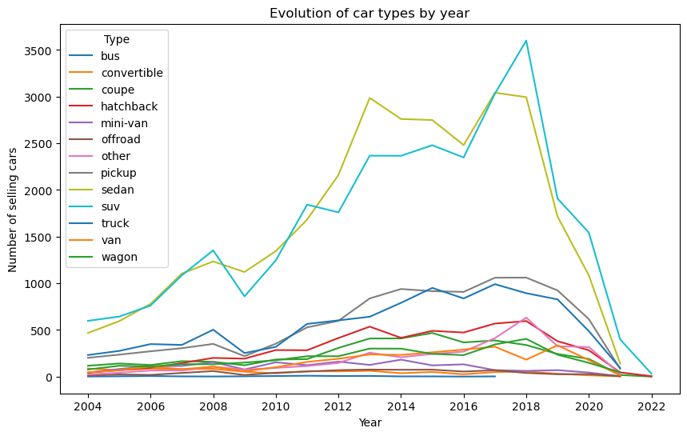

```python
plt.figure(figsize=(10,6))
for vehicle_type, group in pivot_df.groupby('type'):
    plt.plot(group['year'], group['VIN'], label=vehicle_type)
plt.xlabel('Year')
plt.ylabel('Number of selling cars')
plt.xticks(range(2004, 2024, 2))
plt.title('Evolution of car types by year')
plt.legend(title='Type')
plt.show()
```